# Week 4 - Homework

STAT 420, Summer 2020, Hyunjoon Rhee

# Directions

Students are encouraged to work together on homework. However, sharing, copying or providing any part of a homework solution or code is an infraction of the University’s rules on Academic Integrity. Any violation will be punished as severely as possible.

- Be sure to remove this section if you use this `.Rmd` file as a template.
- You may leave the questions in your final document.

## Exercise 1 (Using `lm`)

For this exercise we will use the data stored in `nutrition-2018.csv`. It contains the nutritional values per serving size for a large variety of foods as calculated by the USDA in 2018. It is a cleaned version totaling 5956 observations and is current as of April 2018.

The variables in the dataset are:

- `ID`
- `Desc` - short description of food
- `Water` - in grams
- `Calories`
- `Protein` - in grams
- `Fat` - in grams
- `Carbs` - carbohydrates, in grams
- `Fiber` - in grams
- `Sugar` - in grams
- `Calcium` - in milligrams
- `Potassium` - in milligrams
- `Sodium` - in milligrams
- `VitaminC` - vitamin C, in milligrams
- `Chol` - cholesterol, in milligrams
- `Portion` - description of standard serving size used in analysis

```r
nutritiondata <- data.frame(read.csv('~/Desktop/20Summer/Stat420/Week4/nutrition-2018.csv'))
#View(nutritiondata)
```

**(a)** Fit the following multiple linear regression model in `R`. Use `Calories` as the response and `Fat`, `Sugar`, and `Sodium` as predictors.

$$Y_i = \beta_0 + \beta_1 x_{i1} + \beta_2 x_{i2} + \beta_3 x_{i3} + \epsilon_i.$$

Here,

- $Y_i$ is `Calories`.
- $x_{i1}$ is `Fat`.
- $x_{i2}$ is `Sugar`.
- $x_{i3}$ is `Sodium`.

Use an $F$-test to test the significance of the regression. Report the following:

- The null and alternative hypotheses
- The value of the test statistic
- The p-value of the test
- A statistical decision at $\alpha = 0.01$
- A conclusion in the context of the problem

When reporting these, you should explicitly state them in your document, not assume that a reader will find and interpret them from a large block of `R` output.

```r
model1 <- lm(Calories ~ Fat + Sugar + Sodium, data = nutritiondata)
#summary(model1)
```

- The value of the test statistic

```r
summary(model1)$fstatistic
```

```
##   value   numdf   dendf
## 6590.94    3.00 5952.00
```

- The p-value of the test $2.2e-16$
- A statistical decision at $\alpha = 0.01$ Since p value is smaller than alpha, reject null hypothesis
- A conclusion in the context of the problem There is a relationship among fat, sugar, sodium and calories.

**(b)** Output only the estimated regression coefficients. Interpret all $\hat{\beta}_j$ coefficients in the context of the problem.

```r
coef(model1)[1]
```

```
## (Intercept)
##    100.4561
```

```r
coef(model1)[2]
```

```
##      Fat
## 8.483289
```

```r
coef(model1)[3]
```

```
##    Sugar
## 3.900517
```

```r
coef(model1)[4]
```

```
##      Sodium
## 0.006165246
```

$\hat{\beta}_0$ is found when $\hat{\beta}_1 = \hat{\beta}_2 = \hat{\beta}_3 = 0$ $\hat{\beta}_1$, $\hat{\beta}_2$, $\hat{\beta}_3$ is change of calories of 1 unit increase of fat, sugar, sodium each.

**(c)** Use your model to predict the number of `Calories` in a Big Mac. According to [McDonald’s publicized nutrition facts](https://www.mcdonalds.com/us/en-us/about-our-food/nutrition-calculator.html), the Big Mac contains 30g of fat, 9g of sugar, and 1010mg of sodium.

```r
bigmacdata = data.frame(Fat = 30, Sugar = 9, Sodium = 1.01)
bigmacpredict = predict(model1, newdata = bigmacdata)
bigmacpredict[1]
```

```
##        1
## 390.0656
```

**(d)** Calculate the standard deviation, $s_y$, for the observed values in the Calories variable. Report the value of $s_e$ from your multiple regression model. Interpret both estimates in the context of this problem.

```r
s_y = sd(nutritiondata$Calories)
s_e = summary(model1)$sigma
```

[output not shown]

**(e)** Report the value of $R^2$ for the model. Interpret its meaning in the context of the problem.

```r
summary(model1)
```

```
##
## Call:
## lm(formula = Calories ~ Fat + Sugar + Sodium, data = nutritiondata)
##
## Residuals:
##     Min      1Q  Median      3Q     Max
## -339.41  -64.82   -9.42   28.12  293.54
##
## Coefficients:
##              Estimate Std. Error t value Pr(>|t|)
## (Intercept) 1.005e+02  1.409e+00  71.310  < 2e-16 ***
## Fat         8.483e+00  6.456e-02 131.394  < 2e-16 ***
## Sugar       3.901e+00  7.140e-02  54.627  < 2e-16 ***
## Sodium      6.165e-03  1.030e-03   5.983 2.31e-09 ***
## ---
## Signif. codes:  0 '***' 0.001 '**' 0.01 '*' 0.05 '.' 0.1 ' ' 1
##
## Residual standard error: 80.85 on 5952 degrees of freedom
## Multiple R-squared:  0.7686, Adjusted R-squared:  0.7685
## F-statistic:  6591 on 3 and 5952 DF,  p-value: < 2.2e-16
```

$0.7686$

**(f)** Calculate a 90% confidence interval for $\beta_2$. Give an interpretation of the interval in the context of the problem.

```r
 confint(model1, "Fat", level=0.9)
```

```
##          5 %     95 %
## Fat 8.377075 8.589503
```

My interpretation is that it is 90% confident that mean of fat predicted is in between 8.377 and 8.5895

**(g)** Calculate a 95% confidence interval for $\beta_0$. Give an interpretation of the interval in the context of the problem.

```r
 confint(model1, "(Intercept)", level=0.95)
```

```
##                2.5 %   97.5 %
## (Intercept) 97.69443 103.2177
```

**(h)** Use a 99% confidence interval to estimate the mean Calorie content of a food with 23g of fat, 0g of sugar, and 400mg of sodium, which is true of a large order of McDonald’s french fries. Interpret the interval in context.

```r
frenchfries = data.frame(Fat = 23, Sugar = 0, Sodium = 0.4)
predict(model1, newdata = frenchfries, interval = "confidence", level = 0.99)
```

```
##        fit      lwr      upr
## 1 295.5742 291.8012 299.3471
```

My interpretation is that it is 99% confident that mean of calories predicted is in between 291.8012 and 299.3471

**(i)** Use a 99% prediction interval to predict the Calorie content of a Crunchwrap Supreme, which has 21g of fat, 6g of sugar, and 1200mg of sodium according to [Taco Bell’s publicized nutrition information](https://www.tacobell.com/nutrition/info). Interpret the interval in context.

```r
crunchwrap = data.frame(Fat = 21, Sugar = 6, Sodium = 12)
predict(model1, newdata = crunchwrap, interval = "prediction", level = 0.99)
```

```
##        fit      lwr      upr
## 1 302.0822 93.72181 510.4426
```

My interpretation is that it is 99% confident that mean of calories predicted is in between 93.72181 and 510.4426.

## Exercise 2 (More `lm` for Multiple Regression)

For this exercise we will use the data stored in `goalies.csv`. It contains career data for 462 players in the National Hockey League who played goaltender at some point up to and including the 2014-2015 season. The variables in the dataset are:

- `W` - Wins
- `GA` - Goals Against
- `SA` - Shots Against
- `SV` - Saves
- `SV_PCT` - Save Percentage
- `GAA` - Goals Against Average
- `SO` - Shutouts
- `MIN` - Minutes
- `PIM` - Penalties in Minutes

For this exercise we will consider three models, each with Wins as the response. The predictors for these models are:

- Model 1: Goals Against, Saves
- Model 2: Goals Against, Saves, Shots Against, Minutes, Shutouts
- Model 3: All Available

```r
goaliesdata <- data.frame(read.csv('~/Desktop/20Summer/Stat420/Week4/goalies.csv'))
#View(goaliesdata)
model_1 = lm(W ~ GA + SV, data = goaliesdata)
model_2= lm(W ~ GA + SV + SA + MIN + SO, data = goaliesdata)
model_3 = lm(W ~ ., data = goaliesdata)
```

**(a)** Use an $F$-test to compares Models 1 and 2. Report the following:

```r
anova(model_1,model_2)
```

```
## Analysis of Variance Table
##
## Model 1: W ~ GA + SV
## Model 2: W ~ GA + SV + SA + MIN + SO
##   Res.Df    RSS Df Sum of Sq      F    Pr(>F)
## 1    459 294757
## 2    456  72899  3    221858 462.59 < 2.2e-16 ***
## ---
## Signif. codes:  0 '***' 0.001 '**' 0.01 '*' 0.05 '.' 0.1 ' ' 1
```

- The null hypothesis Null hypothesis: BetaSA = BetaMin = BetaSO = 0
- The value of the test statistic F value is 462.59
- The p-value of the test p value is $2.2e-16$
- A statistical decision at $\alpha = 0.05$ Reject null hypothesis because p value is way smaller than alpha
- The model you prefer I would prefer the larger model 2.

**(b)** Use an $F$-test to compare Model 3 to your preferred model from part **(a)**. Report the following:

```r
anova(model_2,model_3)
```

```
## Analysis of Variance Table
##
## Model 1: W ~ GA + SV + SA + MIN + SO
## Model 2: W ~ GA + SA + SV + SV_PCT + GAA + SO + MIN + PIM
##   Res.Df   RSS Df Sum of Sq     F   Pr(>F)
## 1    456 72899
## 2    453 70994  3    1905.1 4.052 0.007353 **
## ---
## Signif. codes:  0 '***' 0.001 '**' 0.01 '*' 0.05 '.' 0.1 ' ' 1
```

- The null hypothesis Null hypothesis: BetaSV_PCT = BetaGAA = BetaPIM = 0
- The value of the test statistic F value is 4.052
- The p-value of the test p value is 0.007353
- A statistical decision at $\alpha = 0.05$ Reject null hypothesis because p value is smaller than alpha.
- The model you prefer I would prefer larger model 3

**(c)** Use a $t$-test to test $H_0: \beta_{\texttt{SV}} = 0 \ \text{vs} \ H_1: \beta_{\texttt{SV}} \neq 0$ for the model you preferred in part **(b)**. Report the following:

```r
summary(model_3)
```

```
##
## Call:
## lm(formula = W ~ ., data = goaliesdata)
##
## Residuals:
##     Min      1Q  Median      3Q     Max
## -51.204  -3.126   0.935   2.835  64.078
##
## Coefficients:
##               Estimate Std. Error t value Pr(>|t|)
## (Intercept)  5.2651619 16.8181423   0.313 0.754376
## GA          -0.1132805  0.0148085  -7.650 1.22e-13 ***
## SA           0.0516385  0.0135565   3.809 0.000159 ***
## SV          -0.0582151  0.0150905  -3.858 0.000131 ***
## SV_PCT      -8.0475191 17.6600154  -0.456 0.648830
## GAA         -0.0496006  0.4821957  -0.103 0.918116
## SO           0.4599359  0.1989567   2.312 0.021240 *
## MIN          0.0131790  0.0009504  13.867  < 2e-16 ***
## PIM          0.0468422  0.0136373   3.435 0.000647 ***
## ---
## Signif. codes:  0 '***' 0.001 '**' 0.01 '*' 0.05 '.' 0.1 ' ' 1
##
## Residual standard error: 12.52 on 453 degrees of freedom
## Multiple R-squared:  0.9858, Adjusted R-squared:  0.9856
## F-statistic:  3938 on 8 and 453 DF,  p-value: < 2.2e-16
```

- The value of the test statistic t value is -3.858 for SV.
- The p-value of the test p value is 0.000131 for SV
- A statistical decision at $\alpha = 0.05$ Reject null hypothesis because p value is smaller than alpha

## Exercise 3 (Regression without `lm`)

For this exercise we will once again use the `Ozone` data from the `mlbench` package. The goal of this exercise is to fit a model with `ozone` as the response and the remaining variables as predictors.

```r
data(Ozone, package = "mlbench")
Ozone = Ozone[, c(4, 6, 7, 8)]
colnames(Ozone) = c("ozone", "wind", "humidity", "temp")
Ozone = Ozone[complete.cases(Ozone), ]
```

**(a)** Obtain the estimated regression coefficients **without** the use of `lm()` or any other built-in functions for regression. That is, you should use only matrix operations. Store the results in a vector `beta_hat_no_lm`. To ensure this is a vector, you may need to use `as.vector()`. Return this vector as well as the results of `sum(beta_hat_no_lm ^ 2)`.

```r
y = Ozone$ozone
X = cbind(rep(1, length(y)), as.matrix(subset(Ozone, select = -1)))
beta_hat_no_lm = solve(t(X) %*% X) %*% t(X) %*% y
beta_hat_no_lm = as.vector(beta_hat_no_lm)
sum(beta_hat_no_lm ^ 2)
```

```
## [1] 268.5564
```

**(b)** Obtain the estimated regression coefficients **with** the use of `lm()`. Store the results in a vector `beta_hat_lm`. To ensure this is a vector, you may need to use `as.vector()`. Return this vector as well as the results of `sum(beta_hat_lm ^ 2)`.

```r
ozonefit = lm(ozone ~ ., data = Ozone)
#summary(ozonefit)
beta_hat_lm = as.vector(coef(ozonefit))
sum(beta_hat_lm ^ 2)
```

```
## [1] 268.5564
```

**(c)** Use the `all.equal()` function to verify that the results are the same. You may need to remove the names of one of the vectors. The `as.vector()` function will do this as a side effect, or you can directly use `unname()`.

```r
all.equal(beta_hat_no_lm, beta_hat_lm)
```

```
## [1] TRUE
```

**(d)** Calculate $s_e$ without the use of `lm()`. That is, continue with your results from **(a)** and perform additional matrix operations to obtain the result. Output this result. Also, verify that this result is the same as the result obtained from `lm()`.

```r
yhat = X %*% beta_hat_no_lm
y = Ozone$ozone
e = y-yhat
s_e = sqrt((t(e)%*% e)/(length(y) - length(beta_hat_no_lm)))
all.equal(as.vector(s_e), summary(ozonefit)$sigma)
```

```
## [1] TRUE
```

**(e)** Calculate $R^2$ without the use of `lm()`. That is, continue with your results from **(a)** and **(d)**, and perform additional operations to obtain the result. Output this result. Also, verify that this result is the same as the result obtained from `lm()`.

```r
y_mean = mean(y)
SST = sum((y - y_mean) ^ 2)
SSReg = sum((yhat - y_mean) ^ 2)
Rsquare = SSReg / SST
all.equal(Rsquare, summary(ozonefit)$r.squared)
```

```
## [1] TRUE
```

## Exercise 4 (Regression for Prediction)

For this exercise use the `Auto` dataset from the `ISLR` package. Use `?Auto` to learn about the dataset. The goal of this exercise is to find a model that is useful for **predicting** the response `mpg`. We remove the `name` variable as it is not useful for this analysis. (Also, this is an easier to load version of data from the textbook.)

```r
# load required package, remove "name" variable
#install.packages("ISLR")
library(ISLR)
Auto = ISLR::Auto
Auto = subset(Auto, select = -c(name))
```

When evaluating a model for prediction, we often look at RMSE. However, if we both fit the model with all the data as well as evaluate RMSE using all the data, we’re essentially cheating. We’d like to use RMSE as a measure of how well the model will predict on *unseen* data. If you haven’t already noticed, the way we had been using RMSE resulted in RMSE decreasing as models became larger.

To correct for this, we will only use a portion of the data to fit the model, and then we will use leftover data to evaluate the model. We will call these datasets **train** (for fitting) and **test** (for evaluating). The definition of RMSE will stay the same

$$\text{RMSE}(\text{model, data}) = \sqrt{\frac{1}{n} \sum_{i = 1}^{n}(y_i - \hat{y}_i)^2}$$

where

- $y_i$ are the actual values of the response for the given data.
- $\hat{y}_i$ are the predicted values using the fitted model and the predictors from the data.

However, we will now evaluate it on both the **train** set and the **test** set separately. So each model you fit will have a **train** RMSE and a **test** RMSE. When calculating **test** RMSE, the predicted values will be found by predicting the response using the **test** data with the model fit using the **train** data. **Test** data should never be used to fit a model.

- Train RMSE: Model fit with *train* data. Evaluate on **train** data.
- Test RMSE: Model fit with *train* data. Evaluate on **test** data.

Set a seed of `11`, and then split the `Auto` data into two datasets, one called `auto_trn` and one called `auto_tst`. The `auto_trn` data frame should contain 292 randomly chosen observations. The `auto_tst` data will contain the remaining observations. Hint: consider the following code:

```r
set.seed(11)
auto_trn_idx = sample(1:nrow(Auto), 292)
#View(Auto)
auto_trn = Auto[auto_trn_idx, ]
auto_tst = Auto[-auto_trn_idx,]
```

Fit a total of five models using the training data.

```r
model_11 = lm(mpg ~ displacement, data = auto_trn)
model_22 = lm(mpg ~ displacement + weight + acceleration, data = auto_trn)
model_33 = lm(mpg ~ cylinders + displacement + weight + acceleration +year,
           data = auto_trn)
model_44 = lm(mpg ~ cylinders + displacement + weight + acceleration + year +
           origin, data = auto_trn)
model_55 = lm(mpg ~ ., data = auto_trn)
```

- One must use all possible predictors.

```r
y_hat_1train = predict(model_11, newdata = auto_trn)
y_hat_2train = predict(model_22, newdata = auto_trn)
y_hat_3train = predict(model_33, newdata = auto_trn)
y_hat_4train = predict(model_44, newdata = auto_trn)
y_hat_5train = predict(model_55, newdata = auto_trn)

y_hat_1test = predict(model_11, newdata = auto_tst)
y_hat_2test = predict(model_22, newdata = auto_tst)
y_hat_3test = predict(model_33, newdata = auto_tst)
y_hat_4test = predict(model_44, newdata = auto_tst)
y_hat_5test = predict(model_55, newdata = auto_tst)
```

```r
rmse = function(y, y_hat) {
  n = length(y)
  d = y-y_hat
  sqrt(mean(d^2))
}
```

- One must use only `displacement` as a predictor.

```r
rmsetrn1 = rmse(auto_trn$mpg,y_hat_1train)
rmsetrn2 = rmse(auto_trn$mpg,y_hat_2train)
rmsetrn3 = rmse(auto_trn$mpg,y_hat_3train)
rmsetrn4 = rmse(auto_trn$mpg,y_hat_4train)
rmsetrn5 = rmse(auto_trn$mpg,y_hat_5train)

rmsetst1 = rmse(auto_tst$mpg,y_hat_1test)
rmsetst2 = rmse(auto_tst$mpg,y_hat_2test)
rmsetst3 = rmse(auto_tst$mpg,y_hat_3test)
rmsetst4 = rmse(auto_tst$mpg,y_hat_4test)
rmsetst5 = rmse(auto_tst$mpg,y_hat_5test)
```

- The remaining three you can pick to be anything you like. One of these should be the *best* of the five for predicting the response.

For each model report the **train** and **test** RMSE. Arrange your results in a well-formatted markdown table. Argue that one of your models is the best for predicting the response.

```r
rmsetrn = c(rmsetrn1,rmsetrn2,rmsetrn3,rmsetrn4,rmsetrn5)
rmsetst = c(rmsetst1,rmsetst2,rmsetst3,rmsetst4,rmsetst5)
rmse_ = cbind(rmsetrn,rmsetst)
knitr::kable(rmse_)
```

| rmsetrn | rmsetst |
| --- | --- |
| 4.553319 | 4.853014 |
| 4.160033 | 4.564647 |
| 3.339379 | 3.632299 |
| 3.223651 | 3.573443 |
| 3.223650 | 3.572856 |

## Exercise 5 (Simulating Multiple Regression)

For this exercise we will simulate data from the following model:

$$Y_i = \beta_0 + \beta_1 x_{i1} + \beta_2 x_{i2} + \beta_3 x_{i3} + \beta_4 x_{i4} + \beta_5 x_{i5} + \epsilon_i$$

Where $\epsilon_i \sim N(0, \sigma^2).$ Also, the parameters are known to be:

- $\beta_0 = 2$
- $\beta_1 = -0.75$
- $\beta_2 = 1.5$
- $\beta_3 = 0$
- $\beta_4 = 0$
- $\beta_5 = 2$
- $\sigma^2 = 25$

```r
beta_0 = 2
beta_1 = -0.75
beta_2 = 1.5
beta_3 = 0
beta_4 = 0
beta_5 = 2
sigma  = 5
```

We will use samples of size `n = 42`.

We will verify the distribution of $\hat{\beta}_2$ as well as investigate some hypothesis tests.

**(a)** We will first generate the $X$ matrix and data frame that will be used throughout the exercise. Create the following nine variables:

- `x0`: a vector of length `n` that contains all `1`
- `x1`: a vector of length `n` that is randomly drawn from a normal distribution with a mean of `0` and a standard deviation of `2`
- `x2`: a vector of length `n` that is randomly drawn from a uniform distribution between `0` and `4`
- `x3`: a vector of length `n` that is randomly drawn from a normal distribution with a mean of `0` and a standard deviation of `1`
- `x4`: a vector of length `n` that is randomly drawn from a uniform distribution between `-2` and `2`
- `x5`: a vector of length `n` that is randomly drawn from a normal distribution with a mean of `0` and a standard deviation of `2`
- `X`: a matrix that contains `x0`, `x1`, `x2`, `x3`, `x4`, and `x5` as its columns
- `C`: the $C$ matrix that is defined as $(X^\top X)^{-1}$
- `y`: a vector of length `n` that contains all `0`
- `sim_data`: a data frame that stores `y` and the **five** *predictor* variables. `y` is currently a placeholder that we will update during the simulation.

Report the sum of the diagonal of `C` as well as the 5th row of `sim_data`. For this exercise we will use the seed `420`. Generate the above variables in the order listed after running the code below to set a seed.

```r
set.seed(420)
sample_size = 42

x0 = rep(1,sample_size)
x1 = rnorm(sample_size,mean=0,sd=2)
x2 = runif(sample_size,min=0,max=4)
x3 = rnorm(sample_size,mean=0,sd=1)
x4 = runif(sample_size,min=-2,max=2)
x5 = rnorm(sample_size,mean=0,sd=2)
X = cbind(x0,x1,x2,x3,x4,x5)
C = solve(t(X)%*%X)
y = rep(0,sample_size)
sim_data = data.frame(y,x1,x2,x3,x4,x5)

sum(diag(C))
```

```
## [1] 0.1792443
```

```r
sim_data[5,]
```

```
##   y        x1        x2        x3        x4         x5
## 5 0 0.7959582 0.4283331 0.6079313 0.4994189 -0.9018014
```

**(b)** Create three vectors of length `2500` that will store results from the simulation in part **(c)**. Call them `beta_hat_1`, `beta_3_pval`, and `beta_5_pval`.

```r
beta_hat_1 = rep(0,2500)
beta_3_pval = rep(0,2500)
beta_5_pval = rep(0,2500)
```

**(c)** Simulate 2500 samples of size `n = 42` from the model above. Each time update the `y` value of `sim_data`. Then use `lm()` to fit a multiple regression model. Each time store:

```r
for (i in 1:2500) {
  eps = rnorm(sample_size,mean=0,sd=sigma)
  sim_data$y = beta_0+beta_1*x1+beta_2*x2+beta_3*x3+beta_4*x4+beta_5*x5+eps
  model111 = lm(y ~ ., data = sim_data)
  beta_hat_1[i] = coef(model111)[2]
  beta_3_pval[i] = summary(model111)$coefficients[4,"Pr(>|t|)"]
  beta_5_pval[i] = summary(model111)$coefficients[6,"Pr(>|t|)"]
}
summary(model111)$coefficients
```

```
##                Estimate Std. Error    t value    Pr(>|t|)
## (Intercept)  1.33807694  1.7756105  0.7535870 0.455997925
## x1          -0.91678665  0.4912052 -1.8664027 0.070147616
## x2           1.72683160  0.8110870  2.1290337 0.040162036
## x3           0.50680294  0.8785208  0.5768821 0.567609215
## x4           0.04402528  0.7021822  0.0626978 0.950353975
## x5           2.12359046  0.6305176  3.3680114 0.001814905
```

- The value of $\hat{\beta}_1$ in `beta_hat_1`
- The p-value for the two-sided test of $\beta_3 = 0$ in `beta_3_pval`
- The p-value for the two-sided test of $\beta_5 = 0$ in `beta_5_pval`

**(d)** Based on the known values of $X$, what is the true distribution of $\hat{\beta}_1$?

```r
sigma^2 * C[2, 2]
```

```
## [1] 0.1892102
```

$\hat{\beta}_1 \sim N\left(\mu = \beta_1, \sigma^2 = \sigma^2 * C[2, 2])$

**(e)** Calculate the mean and variance of `beta_hat_1`. Are they close to what we would expect? Plot a histogram of `beta_hat_1`. Add a curve for the true distribution of $\hat{\beta}_1$. Does the curve seem to match the histogram?

They are close to what we expect, and the curve seem to match as well.

```r
mean(beta_hat_1)
```

```
## [1] -0.7461209
```

```r
var(beta_hat_1)
```

```
## [1] 0.1853515
```

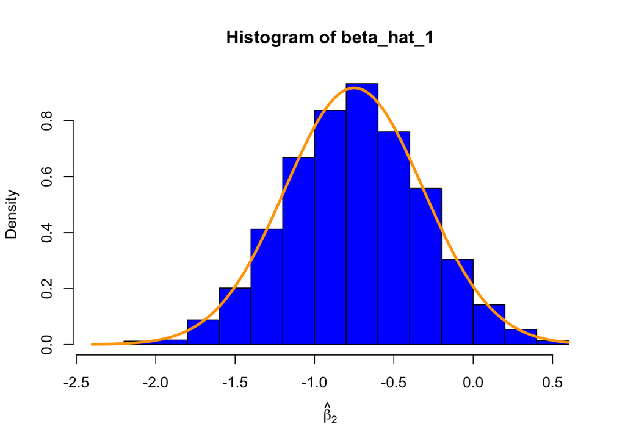

```r
hist(beta_hat_1, prob = TRUE, breaks = 20, xlab = expression(hat(beta)[2]),
     border = "black", col = "blue")
curve(dnorm(x, mean = beta_1, sd = sqrt(sigma^2*C[1 + 1, 1 + 1])),
      col = "orange", add = TRUE, lwd = 3)
```

**(f)** What proportion of the p-values stored in `beta_3_pval` is less than 0.10? Is this what you would expect?

```r
mean(beta_3_pval < 0.10)
```

```
## [1] 0.096
```

It is expected value.

**(g)** What proportion of the p-values stored in `beta_5_pval` is less than 0.01? Is this what you would expect?

```r
mean(beta_5_pval < 0.01)
```

```
## [1] 0.7956
```

It is expected.